# Taller 4

Julian Velandia, Julian Albarracín, Tomas Bermudez

2025-06-24

# 1 Desarrollo

## 1.1 Primer punto

*Enunciado:* Una variable aleatoria $X$ que toma los valores $x_1, x_2, \ldots, x_n$ se denomina variable aleatoria discreta uniforme si su función de masa de probabilidad es:

$$f(x) =
\begin{cases}
1/k & \text{para todas las variables } x_1, x_2, \ldots, x_k \\
0 & \text{en cualquier otro caso.}
\end{cases}$$
Calcule la media y la varianza de $X$.

*Solución:*
$$\begin{align*}
\mu &= E(X) \\
&= \sum_{i=1}^{k} x_i P(x_i) \\
&= \sum_{i=1}^{k} x_i \left(\frac{1}{k}\right) \\
&= \frac{1}{k} \sum_{i=1}^{k} x_i
\end{align*}$$

## 1.2 Segundo punto

*Enunciado:* De acuerdo con un artículo de una revista importante, aproximadamente 30% de todas las fallas de operación en las tuberías de plantas químicas son ocasionadas por errores del operador.

1. ¿Cuál es la probabilidad de que de las siguientes 20 fallas en las tuberías al menos 10 se deban a un error del operador?
2. ¿Cuál es la probabilidad de que no más de 4 de 20 fallas se deban a un error del operador?

*Solución:*
$$P(X \ge 10) = \sum_{i=10}^{20} \binom{20}{i} (0.3)^i (0.7)^{20-i}$$

$$P(X \le 4) = \sum_{i=0}^{4} \binom{20}{i} (0.3)^i (0.7)^{20-i}$$

```
## P(X>=10) =  0.0479619
```

```
## P(X<=4) =  0.2375078
```

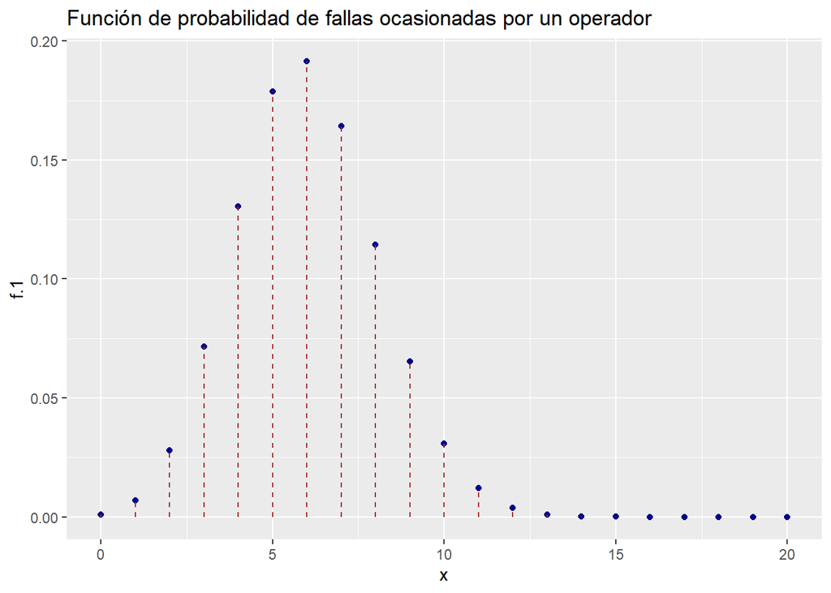

## 1.3 Tercer punto

*Enunciado:* Suponga que los motores de un avión operan de forma independiente y que tienen una probabilidad de falla de 0.4. Se supone que un avión tiene un vuelo seguro si funcionan al menos la mitad de sus motores. Si un avión tiene 4 motores y otro tiene 2, ¿cuál de los dos tiene la probabilidad más alta de un vuelo exitoso?

*Solución:*
$$\begin{aligned}
\text{Para 4 motores: } & P(\text{éxito}) = P(X \ge 2) =
\sum_{i=2}^{4} \binom{4}{i} (0.6)^i (0.4)^{4-i} \\
& = 0.8208 \\
\text{Para 2 motores: } & P(\text{éxito}) = P(Y \ge 1) =
\sum_{i=1}^{2} \binom{2}{i} (0.6)^i (0.4)^{2-i} \\
& = 0.84 \\
\end{aligned}$$

```
## Avion con 4 motores: P(X>=2) =  0.8208
```

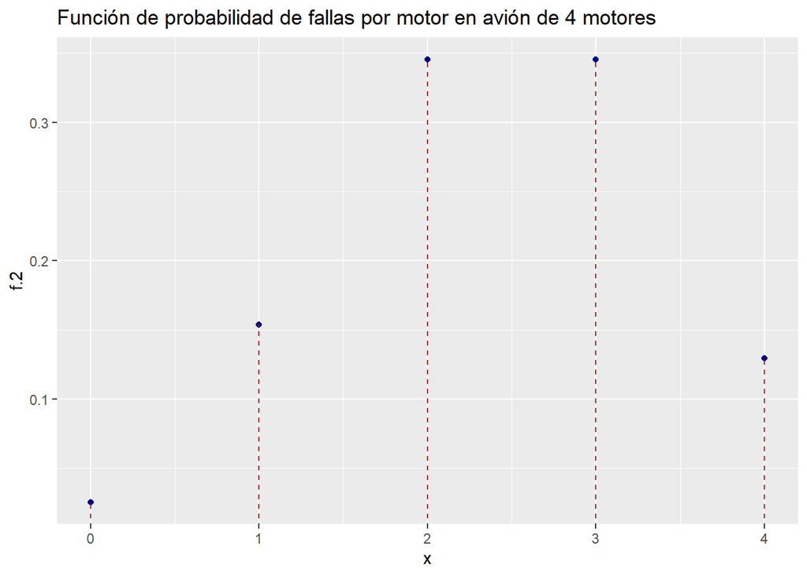

```
## Avion con 2 motores: P(X>=1) =  0.84
```

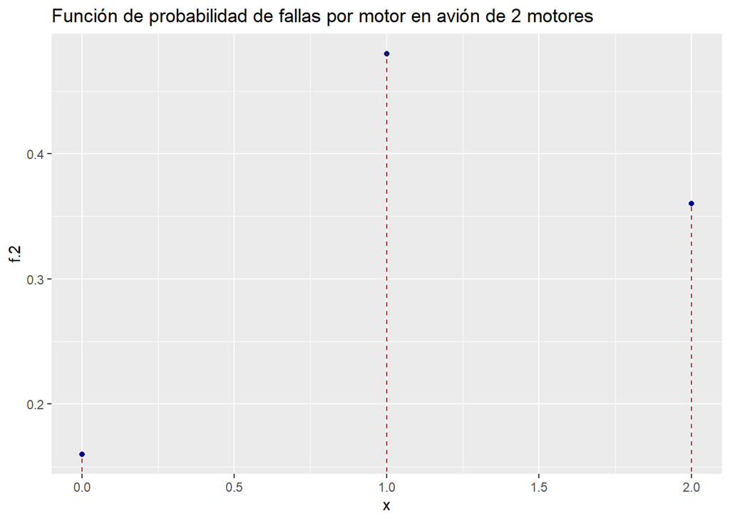

De acuerdo a lo anterior, el avión con 2 motores tiene una mayor probabilidad

## 1.4 Cuarto punto

*Enunciado:* Para evitar la detección en la aduana, un viajero coloca 6 comprimidos con narcóticos en una botella que contiene 9 píldoras de vitamina que aparentemente son similares. Si el oficial de la aduana selecciona 3 de las tabletas al azar para su análisis, ¿cuál es la probabilidad de que el viajero sea arrestado por posesión ilegal de narcóticos?

*Solución:*

```
## La probabilidad de que el viajero sea arrestado es de:  0.8153846
```

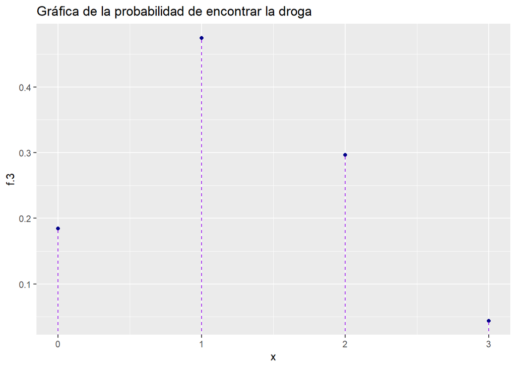

## 1.5 Quinto punto

*Enunciado:* Se selecciona al azar un comité de 3 personas a partir de 4 médicos y 2 enfermeras. Escriba una fórmula para la distribución de probabilidad de la variable aleatoria $X$ que representa el número de médicos en el comité. Calcule $P(2 ≤ X ≤ 3)$

*Solución:* $P(X = x) = \frac{\binom{4}{x}\binom{2}{3-x}}{\binom{6}{3}}$

Como la cantidad de seleccionados es 3, solo tenemos que hallar la probabilidad de que halla dos o más medicos, o sea más de un médico

```
## La probabilidad de haya entre 2 y 3 médicos en el comité es:  0.8
```

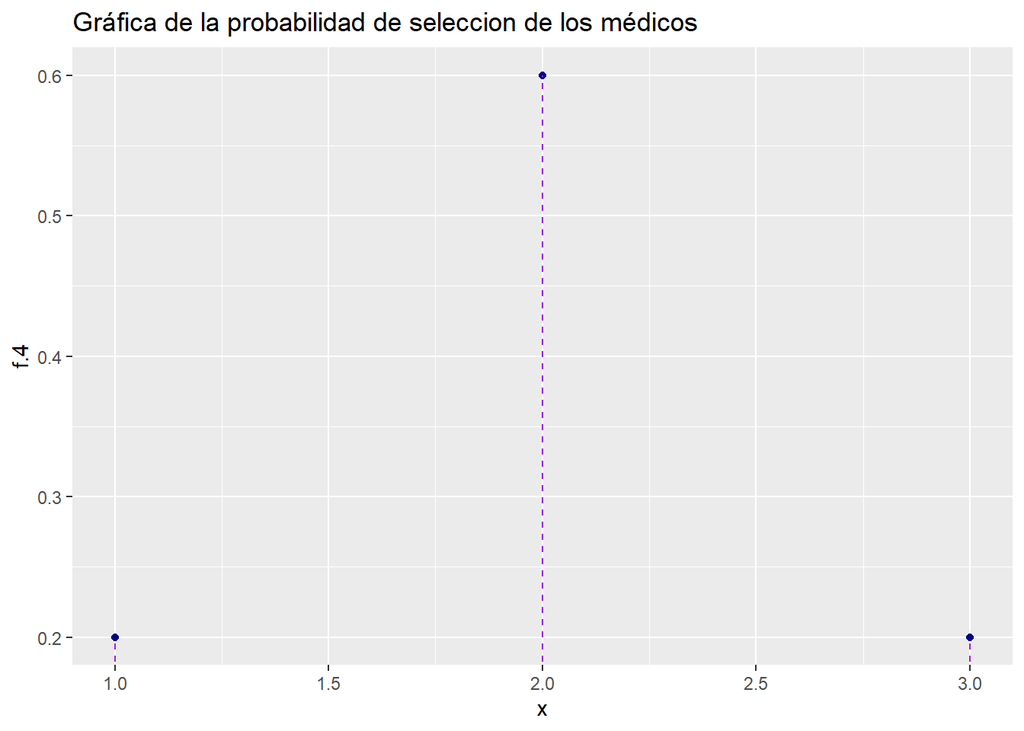

## 1.6 Sexto punto

*Enunciado:* De un lote de 10 misiles, se seleccionan 4 al azar y se disparan. Si el lote contiene 3 misiles defectuosos que no pueden dispararse, ¿cuál es la probabilidad de que:

1. Los 4 puedan dispararse?
2. A lo sumo fallen 2?

*Solución:*

```
## La probabilidad de que los 4 misiles sirvan es:  0.1666667
```

```
## La probabilidad de que a lo sumo dos fallen es:  0.9666667
```

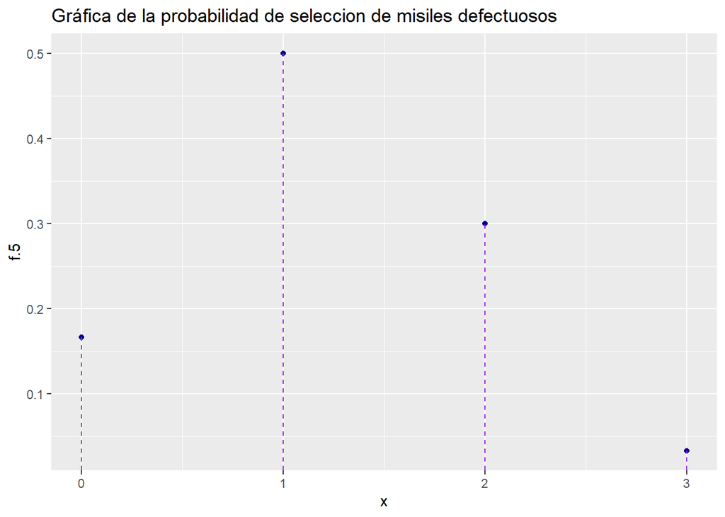

## 1.7 Septimo punto

*Enunciado:* En cierto crucero ocurren, en promedio, 3 accidentes de tránsito al mes. ¿Cuál es la probabilidad de que en cualquier determinado mes en este crucero

1. ocurran exactamente 5 accidentes?
2. ocurran menos de 3 accidentes?
3. ocurran al menos 2 accidentes?

*Solución:*

```
## La probabilidad de que ocurran 5 accidentes es: 0.1008188
```

```
## La probabilidad de que ocurran menos de 3 accidentes es: 0.4231901
```

```
## La probabilidad de que ocurran al menos 2 accidentes es: 0.8008517
```

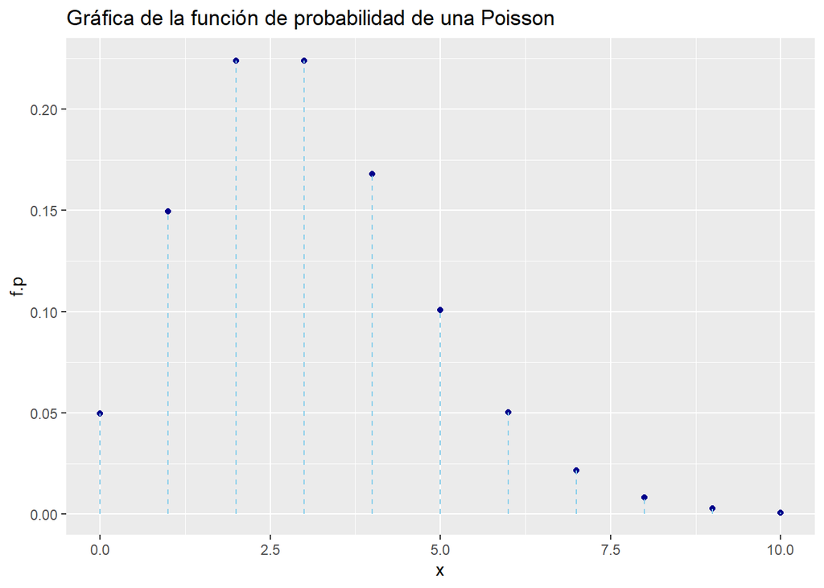

## 1.8 Octavo punto

*Enunciado:* Los cambios en los procedimientos de los aeropuertos requieren una planeación considerable. Los índices de llegadas los aviones son factores importantes que deben tomarse en cuenta. Suponga que los aviones pequeños llegan a cierto aeropuerto, de acuerdo con un proceso de Poisson, con una frecuencia de 6 por hora. De esta manera, el parámetro de Poisson para las llegadas en un periodo de horas es μ = 6t.

1. ¿Cuál es la probabilidad de que lleguen exactamente 4 aviones pequeños durante un periodo de una hora?
2. ¿Cuál es la probabilidad de que lleguen al menos 4 durante un periodo de una hora?
3. Si definimos un día laboral como de 12 horas, ¿cuál es la probabilidad de que al menos 75 aviones pequeños lleguen durante un día laboral?

*Solución:*

```
## La probabilidad de que lleguen 4 aviones en una hora: 0.1338526
```

```
## La probabilidad de que lleguen 4 aviones en una hora: 0.8487961
```

```
## La probabilidad de que lleguen por lo menos 75 aviones en las 12 horas es: 0.3773273
```

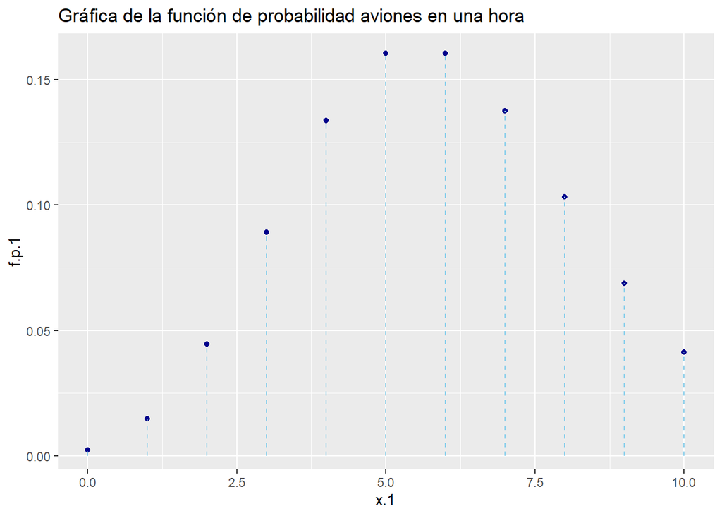

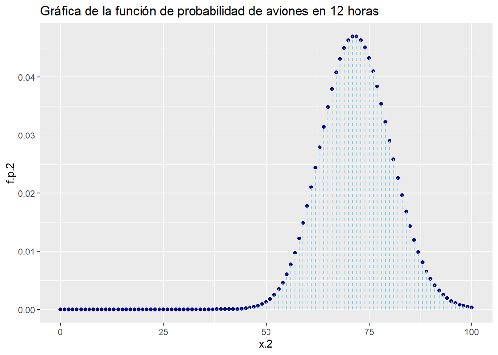

# 2 Notas

La personalización de este trabajo, es decir, la modificación del tema **darkly** mediante el archivo *css* fue posible gracias al trabajo cooperativo con Chatgpt, junto con su ayuda explicando como crear y personalizar las gráficas y funciones.

# 3 Bibliografía

[Probabilidad y Estadística para Ingeniería y Ciencias (9a Edición)](https://bibliotecavirtualaserena.wordpress.com/wp-content/uploads/2017/05/libro_probabilidad-y-estadistica-para-ingenerc3ada-y-ciencias-ronald-e-walpole-mayers.pdf)